# Project_01_MovieLens_Data_Analysis_TH

### Project - MovieLens Data Analysis

The GroupLens Research Project is a research group in the Department of Computer Science and Engineering at the University of Minnesota. The data is widely used for collaborative filtering and other filtering solutions. However, we will be using this data to act as a means to demonstrate our skill in using Python to “play” with data.

#### Domain

Internet and Entertainment

**Note that the project will need you to apply the concepts of groupby and merging extensively.**

**This is Project 01 MovieLens Data Analysis submitted by Tariq Alhefny (TH) on 19-Jun-20**

Having my 1st time experience with both, [1] coding and [2] Python which is challenging so there are a few notes labelled as 'TH Note' to explain either a step or the concept of having such step and other remarks as explained therein.

I am still having difficulties mainly in syntax and commands to generate the required results

I couldn't meet the deadline due to the difficulties above.

Thank you for your understanding and I assure you of my dedication in completing this Porgram despite of the present challenges.

#### 1. Import the necessary packages - 2.5 marks

```python
import numpy as np
import pandas as pd
import matplotlib.pyplot as plt
import seaborn as sns
sns.set(style="darkgrid")
```

#### 2. Read the 3 datasets into dataframes - 2.5 marks

```python
Data = pd.read_csv('Data.csv')
Data.head()
```

|  | user id | movie id | rating | timestamp |
| --- | --- | --- | --- | --- |
| 0 | 196 | 242 | 3 | 881250949 |
| 1 | 186 | 302 | 3 | 891717742 |
| 2 | 22 | 377 | 1 | 878887116 |
| 3 | 244 | 51 | 2 | 880606923 |
| 4 | 166 | 346 | 1 | 886397596 |

```python
Item = pd.read_csv('item.csv')
Item.head()
```

|  | movie id | movie title | release date | unknown | Action | Adventure | Animation | Childrens | Comedy | Crime | ... | Fantasy | Film-Noir | Horror | Musical | Mystery | Romance | Sci-Fi | Thriller | War | Western |
| --- | --- | --- | --- | --- | --- | --- | --- | --- | --- | --- | --- | --- | --- | --- | --- | --- | --- | --- | --- | --- | --- |
| 0 | 1 | Toy Story | 01-Jan-1995 | 0 | 0 | 0 | 1 | 1 | 1 | 0 | ... | 0 | 0 | 0 | 0 | 0 | 0 | 0 | 0 | 0 | 0 |
| 1 | 2 | GoldenEye | 01-Jan-1995 | 0 | 1 | 1 | 0 | 0 | 0 | 0 | ... | 0 | 0 | 0 | 0 | 0 | 0 | 0 | 1 | 0 | 0 |
| 2 | 3 | Four Rooms | 01-Jan-1995 | 0 | 0 | 0 | 0 | 0 | 0 | 0 | ... | 0 | 0 | 0 | 0 | 0 | 0 | 0 | 1 | 0 | 0 |
| 3 | 4 | Get Shorty | 01-Jan-1995 | 0 | 1 | 0 | 0 | 0 | 1 | 0 | ... | 0 | 0 | 0 | 0 | 0 | 0 | 0 | 0 | 0 | 0 |
| 4 | 5 | Copycat | 01-Jan-1995 | 0 | 0 | 0 | 0 | 0 | 0 | 1 | ... | 0 | 0 | 0 | 0 | 0 | 0 | 0 | 1 | 0 | 0 |

5 rows × 22 columns

```python
User = pd.read_csv('user.csv')
User.head()
```

|  | user id | age | gender | occupation | zip code |
| --- | --- | --- | --- | --- | --- |
| 0 | 1 | 24 | M | technician | 85711 |
| 1 | 2 | 53 | F | other | 94043 |
| 2 | 3 | 23 | M | writer | 32067 |
| 3 | 4 | 24 | M | technician | 43537 |
| 4 | 5 | 33 | F | other | 15213 |

#### 3. Apply info, shape, describe, and find the number of missing values in the data - 5 marks

**TH Note ..** Applying: info, shape and describe individually on each Datafarme. This Step will include checking [1] for duplicates and [2] Find missing values, and [3] clearing them, as applicable.

```python
Data.info()
```

```
<class 'pandas.core.frame.DataFrame'>
RangeIndex: 100000 entries, 0 to 99999
Data columns (total 4 columns):
 #   Column     Non-Null Count   Dtype
---  ------     --------------   -----
 0   user id    100000 non-null  int64
 1   movie id   100000 non-null  int64
 2   rating     100000 non-null  int64
 3   timestamp  100000 non-null  int64
dtypes: int64(4)
memory usage: 3.1 MB
```

```python
Data.shape
```

```
(100000, 4)
```

```python
Data.describe()
```

|  | user id | movie id | rating | timestamp |
| --- | --- | --- | --- | --- |
| count | 100000.00000 | 100000.000000 | 100000.000000 | 1.000000e+05 |
| mean | 462.48475 | 425.530130 | 3.529860 | 8.835289e+08 |
| std | 266.61442 | 330.798356 | 1.125674 | 5.343856e+06 |
| min | 1.00000 | 1.000000 | 1.000000 | 8.747247e+08 |
| 25% | 254.00000 | 175.000000 | 3.000000 | 8.794487e+08 |
| 50% | 447.00000 | 322.000000 | 4.000000 | 8.828269e+08 |
| 75% | 682.00000 | 631.000000 | 4.000000 | 8.882600e+08 |
| max | 943.00000 | 1682.000000 | 5.000000 | 8.932866e+08 |

```python
Item.info()
```

```
<class 'pandas.core.frame.DataFrame'>
RangeIndex: 1681 entries, 0 to 1680
Data columns (total 22 columns):
 #   Column        Non-Null Count  Dtype
---  ------        --------------  -----
 0   movie id      1681 non-null   int64
 1   movie title   1681 non-null   object
 2   release date  1681 non-null   object
 3   unknown       1681 non-null   int64
 4   Action        1681 non-null   int64
 5   Adventure     1681 non-null   int64
 6   Animation     1681 non-null   int64
 7   Childrens     1681 non-null   int64
 8   Comedy        1681 non-null   int64
 9   Crime         1681 non-null   int64
 10  Documentary   1681 non-null   int64
 11  Drama         1681 non-null   int64
 12  Fantasy       1681 non-null   int64
 13  Film-Noir     1681 non-null   int64
 14  Horror        1681 non-null   int64
 15  Musical       1681 non-null   int64
 16  Mystery       1681 non-null   int64
 17  Romance       1681 non-null   int64
 18  Sci-Fi        1681 non-null   int64
 19  Thriller      1681 non-null   int64
 20  War           1681 non-null   int64
 21  Western       1681 non-null   int64
dtypes: int64(20), object(2)
memory usage: 289.0+ KB
```

```python
Item.shape
```

```
(1681, 22)
```

```python
Item.describe()
```

|  | movie id | unknown | Action | Adventure | Animation | Childrens | Comedy | Crime | Documentary | Drama | Fantasy | Film-Noir | Horror | Musical | Mystery | Romance | Sci-Fi | Thriller | War | Western |
| --- | --- | --- | --- | --- | --- | --- | --- | --- | --- | --- | --- | --- | --- | --- | --- | --- | --- | --- | --- | --- |
| count | 1681.000000 | 1681.000000 | 1681.000000 | 1681.000000 | 1681.000000 | 1681.000000 | 1681.000000 | 1681.000000 | 1681.000000 | 1681.000000 | 1681.000000 | 1681.000000 | 1681.000000 | 1681.000000 | 1681.000000 | 1681.000000 | 1681.000000 | 1681.000000 | 1681.000000 | 1681.000000 |
| mean | 841.841761 | 0.000595 | 0.149316 | 0.080309 | 0.024985 | 0.072576 | 0.300416 | 0.064842 | 0.029744 | 0.431291 | 0.013087 | 0.014277 | 0.054729 | 0.033314 | 0.036288 | 0.146936 | 0.060083 | 0.149316 | 0.042237 | 0.016062 |
| std | 485.638077 | 0.024390 | 0.356506 | 0.271852 | 0.156126 | 0.259516 | 0.458576 | 0.246321 | 0.169931 | 0.495404 | 0.113683 | 0.118667 | 0.227519 | 0.179507 | 0.187061 | 0.354148 | 0.237712 | 0.356506 | 0.201189 | 0.125751 |
| min | 1.000000 | 0.000000 | 0.000000 | 0.000000 | 0.000000 | 0.000000 | 0.000000 | 0.000000 | 0.000000 | 0.000000 | 0.000000 | 0.000000 | 0.000000 | 0.000000 | 0.000000 | 0.000000 | 0.000000 | 0.000000 | 0.000000 | 0.000000 |
| 25% | 422.000000 | 0.000000 | 0.000000 | 0.000000 | 0.000000 | 0.000000 | 0.000000 | 0.000000 | 0.000000 | 0.000000 | 0.000000 | 0.000000 | 0.000000 | 0.000000 | 0.000000 | 0.000000 | 0.000000 | 0.000000 | 0.000000 | 0.000000 |
| 50% | 842.000000 | 0.000000 | 0.000000 | 0.000000 | 0.000000 | 0.000000 | 0.000000 | 0.000000 | 0.000000 | 0.000000 | 0.000000 | 0.000000 | 0.000000 | 0.000000 | 0.000000 | 0.000000 | 0.000000 | 0.000000 | 0.000000 | 0.000000 |
| 75% | 1262.000000 | 0.000000 | 0.000000 | 0.000000 | 0.000000 | 0.000000 | 1.000000 | 0.000000 | 0.000000 | 1.000000 | 0.000000 | 0.000000 | 0.000000 | 0.000000 | 0.000000 | 0.000000 | 0.000000 | 0.000000 | 0.000000 | 0.000000 |
| max | 1682.000000 | 1.000000 | 1.000000 | 1.000000 | 1.000000 | 1.000000 | 1.000000 | 1.000000 | 1.000000 | 1.000000 | 1.000000 | 1.000000 | 1.000000 | 1.000000 | 1.000000 | 1.000000 | 1.000000 | 1.000000 | 1.000000 | 1.000000 |

```python
User.info()
```

```
<class 'pandas.core.frame.DataFrame'>
RangeIndex: 943 entries, 0 to 942
Data columns (total 5 columns):
 #   Column      Non-Null Count  Dtype
---  ------      --------------  -----
 0   user id     943 non-null    int64
 1   age         943 non-null    int64
 2   gender      943 non-null    object
 3   occupation  943 non-null    object
 4   zip code    943 non-null    object
dtypes: int64(2), object(3)
memory usage: 37.0+ KB
```

```python
User.shape
```

```
(943, 5)
```

```python
User.describe()
```

|  | user id | age |
| --- | --- | --- |
| count | 943.000000 | 943.000000 |
| mean | 472.000000 | 34.051962 |
| std | 272.364951 | 12.192740 |
| min | 1.000000 | 7.000000 |
| 25% | 236.500000 | 25.000000 |
| 50% | 472.000000 | 31.000000 |
| 75% | 707.500000 | 43.000000 |
| max | 943.000000 | 73.000000 |

**TH Note ..** Finding Duplicates in the 3 DataFrames

```python
Dupes_Data = Data.duplicated()
sum(Dupes_Data)
print('Data Duplicates:', sum(Dupes_Data))
Dupes_Item = Item.duplicated()
sum(Dupes_Item)
print('Items Duplicates:', sum(Dupes_Item))
Dupes_User = User.duplicated()
sum(Dupes_User)
print('User Duplicates:', sum(Dupes_User))
```

```
Data Duplicates: 0
Items Duplicates: 0
User Duplicates: 0
```

**TH Note ..** Finding the number of missing values in the 3 DataFrames

```python
pd.DataFrame(Data.isnull().sum(),columns = ['Number of Missing Values in Data'])
```

|  | Number of Missing Values in Data |
| --- | --- |
| user id | 0 |
| movie id | 0 |
| rating | 0 |
| timestamp | 0 |

**TH Note ..** Or may use the below as an aletrnative to find the number of missing values

```python
Data.isnull().sum().sum()
Missing_Data = Data.isnull().sum().sum()
print('Total Number of Missing Values in df_Data:', Missing_Data)
```

```
Total Number of Missing Values in df_Data: 0
```

```python
Item.isnull().sum().sum()
Missing_Item = Item.isnull().sum().sum()
print('Total Number of Missing Values in df_Item:', Missing_Item)
```

```
Total Number of Missing Values in df_Item: 0
```

```python
User.isnull().sum().sum()
Missing_User = Item.isnull().sum().sum()
print('Total Number of Missing Values in df_User:', Missing_User)
```

```
Total Number of Missing Values in df_User: 0
```

#### 4. Find the number of movies per genre using the item data - 5 marks

```python
# use sum on the default axis
```

```python
Item1 = Item.drop(['movie id', 'movie title', 'release date'], axis = 1)
pd.DataFrame(Item1.sum(), columns = ['Number of Movies/Genre'])
```

|  | Number of Movies/Genre |
| --- | --- |
| unknown | 1 |
| Action | 251 |
| Adventure | 135 |
| Animation | 42 |
| Childrens | 122 |
| Comedy | 505 |
| Crime | 109 |
| Documentary | 50 |
| Drama | 725 |
| Fantasy | 22 |
| Film-Noir | 24 |
| Horror | 92 |
| Musical | 56 |
| Mystery | 61 |
| Romance | 247 |
| Sci-Fi | 101 |
| Thriller | 251 |
| War | 71 |
| Western | 27 |

#### 5. Find the movies that have more than one genre - 2.5 marks

```python
#hint: use sum on the axis = 1
```

```python
Item.columns
```

```
Index(['movie id', 'movie title', 'release date', 'unknown', 'Action',
       'Adventure', 'Animation', 'Childrens', 'Comedy', 'Crime', 'Documentary',
       'Drama', 'Fantasy', 'Film-Noir', 'Horror', 'Musical', 'Mystery',
       'Romance', 'Sci-Fi', 'Thriller', 'War', 'Western'],
      dtype='object')
```

```python
Item1=Item[['movie id','movie title']]
Item1.head()
```

|  | movie id | movie title |
| --- | --- | --- |
| 0 | 1 | Toy Story |
| 1 | 2 | GoldenEye |
| 2 | 3 | Four Rooms |
| 3 | 4 | Get Shorty |
| 4 | 5 | Copycat |

```python
Item1['Total of Genres']=Item [['unknown', 'Action',
       'Adventure', 'Animation', 'Childrens', 'Comedy', 'Crime', 'Documentary',
       'Drama', 'Fantasy', 'Film-Noir', 'Horror', 'Musical', 'Mystery',
       'Romance', 'Sci-Fi', 'Thriller', 'War', 'Western']].sum(axis = 1)
Item1.head()
```

|  | movie id | movie title | Total of Genres |
| --- | --- | --- | --- |
| 0 | 1 | Toy Story | 3 |
| 1 | 2 | GoldenEye | 3 |
| 2 | 3 | Four Rooms | 1 |
| 3 | 4 | Get Shorty | 3 |
| 4 | 5 | Copycat | 3 |

```python
Item1[Item1['Total of Genres']>1]
```

|  | movie id | movie title | Total of Genres |
| --- | --- | --- | --- |
| 0 | 1 | Toy Story | 3 |
| 1 | 2 | GoldenEye | 3 |
| 3 | 4 | Get Shorty | 3 |
| 4 | 5 | Copycat | 3 |
| 6 | 7 | Twelve Monkeys | 2 |
| ... | ... | ... | ... |
| 1667 | 1669 | MURDER and murder | 3 |
| 1668 | 1670 | Tainted | 2 |
| 1671 | 1673 | Mirage | 2 |
| 1677 | 1679 | B. Monkey | 2 |
| 1678 | 1680 | Sliding Doors | 2 |

849 rows × 3 columns

#### 6. Drop the movie where the genre is unknown - 2.5 marks

**TH Note ..** From the **Number of Movies per Genre** Only one movie has **unknown** rating

```python
Item.loc[Item.loc[:,'unknown']==1]
```

|  | movie id | movie title | release date | unknown | Action | Adventure | Animation | Childrens | Comedy | Crime | ... | Fantasy | Film-Noir | Horror | Musical | Mystery | Romance | Sci-Fi | Thriller | War | Western |
| --- | --- | --- | --- | --- | --- | --- | --- | --- | --- | --- | --- | --- | --- | --- | --- | --- | --- | --- | --- | --- | --- |
| 1371 | 1373 | Good Morning | 4-Feb-1971 | 1 | 0 | 0 | 0 | 0 | 0 | 0 | ... | 0 | 0 | 0 | 0 | 0 | 0 | 0 | 0 | 0 | 0 |

1 rows × 22 columns

**TH Note ..** List of movies without the **unknown Genre** will be as follows

```python
Item[Item['unknown']==0]
```

|  | movie id | movie title | release date | unknown | Action | Adventure | Animation | Childrens | Comedy | Crime | ... | Fantasy | Film-Noir | Horror | Musical | Mystery | Romance | Sci-Fi | Thriller | War | Western |
| --- | --- | --- | --- | --- | --- | --- | --- | --- | --- | --- | --- | --- | --- | --- | --- | --- | --- | --- | --- | --- | --- |
| 0 | 1 | Toy Story | 01-Jan-1995 | 0 | 0 | 0 | 1 | 1 | 1 | 0 | ... | 0 | 0 | 0 | 0 | 0 | 0 | 0 | 0 | 0 | 0 |
| 1 | 2 | GoldenEye | 01-Jan-1995 | 0 | 1 | 1 | 0 | 0 | 0 | 0 | ... | 0 | 0 | 0 | 0 | 0 | 0 | 0 | 1 | 0 | 0 |
| 2 | 3 | Four Rooms | 01-Jan-1995 | 0 | 0 | 0 | 0 | 0 | 0 | 0 | ... | 0 | 0 | 0 | 0 | 0 | 0 | 0 | 1 | 0 | 0 |
| 3 | 4 | Get Shorty | 01-Jan-1995 | 0 | 1 | 0 | 0 | 0 | 1 | 0 | ... | 0 | 0 | 0 | 0 | 0 | 0 | 0 | 0 | 0 | 0 |
| 4 | 5 | Copycat | 01-Jan-1995 | 0 | 0 | 0 | 0 | 0 | 0 | 1 | ... | 0 | 0 | 0 | 0 | 0 | 0 | 0 | 1 | 0 | 0 |
| ... | ... | ... | ... | ... | ... | ... | ... | ... | ... | ... | ... | ... | ... | ... | ... | ... | ... | ... | ... | ... | ... |
| 1676 | 1678 | Mat' i syn | 06-Feb-1998 | 0 | 0 | 0 | 0 | 0 | 0 | 0 | ... | 0 | 0 | 0 | 0 | 0 | 0 | 0 | 0 | 0 | 0 |
| 1677 | 1679 | B. Monkey | 06-Feb-1998 | 0 | 0 | 0 | 0 | 0 | 0 | 0 | ... | 0 | 0 | 0 | 0 | 0 | 1 | 0 | 1 | 0 | 0 |
| 1678 | 1680 | Sliding Doors | 01-Jan-1998 | 0 | 0 | 0 | 0 | 0 | 0 | 0 | ... | 0 | 0 | 0 | 0 | 0 | 1 | 0 | 0 | 0 | 0 |
| 1679 | 1681 | You So Crazy | 01-Jan-1994 | 0 | 0 | 0 | 0 | 0 | 1 | 0 | ... | 0 | 0 | 0 | 0 | 0 | 0 | 0 | 0 | 0 | 0 |
| 1680 | 1682 | Scream of Stone (Schrei aus Stein) | 08-Mar-1996 | 0 | 0 | 0 | 0 | 0 | 0 | 0 | ... | 0 | 0 | 0 | 0 | 0 | 0 | 0 | 0 | 0 | 0 |

1680 rows × 22 columns

### 7. Univariate plots of columns: 'rating', 'Age', 'release year', 'Gender' and 'Occupation' - 10 marks

```python
# HINT: use distplot for age and countplot for gender,ratings,occupation.
# HINT: Please refer to the below snippet to understand how to get to release year from release date. You can use str.split()
# as depicted below
# Hint : Use displot without kde for release year or line plot showing year wise count.
```

```python
a = 'My*cat*is*brown'
print(a.split('*')[3])

#similarly, the release year needs to be taken out from release date

#also you can simply slice existing string to get the desired data, if we want to take out the colour of the cat

print(a[10:])
print(a[-5:])
```

```
brown
brown
brown
```

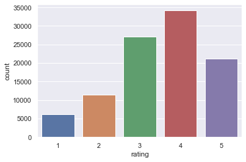

```python
sns.countplot(Data['rating'])
plt.show()
```

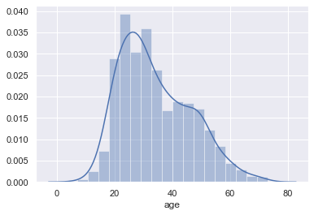

```python
sns.distplot(User['age'])
plt.show()
```

**TH Note ..** I couldn't resolve the Release Year from the Release Date **until** it was cleard after the Mentor Session on 19-Jun-20

```python
Item['release date'].head()
```

```
0    01-Jan-1995
1    01-Jan-1995
2    01-Jan-1995
3    01-Jan-1995
4    01-Jan-1995
Name: release date, dtype: object
```

```python
Item['release year'] = Item['release date'].str[-4:].astype('int')
print(Item['release year'])
```

```
0       1995
1       1995
2       1995
3       1995
4       1995
        ...
1676    1998
1677    1998
1678    1998
1679    1994
1680    1996
Name: release year, Length: 1681, dtype: int32
```

```python
Item.groupby("release year")["release year"].count()
```

```
release year
1922      1
1926      1
1930      1
1931      1
1932      1
       ...
1994    214
1995    219
1996    355
1997    286
1998     65
Name: release year, Length: 71, dtype: int64
```

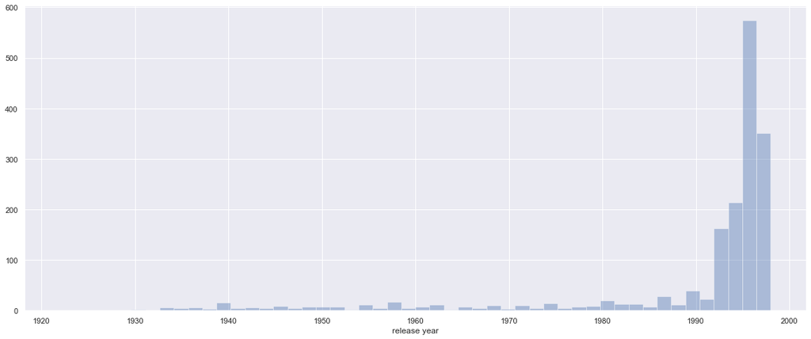

```python
plt.figure(figsize=(20,8))
sns.distplot(Item['release year'],kde=False)
plt.show()
```

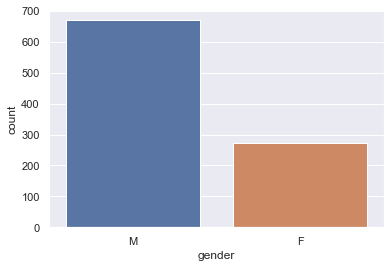

```python
sns.countplot(User['gender'])
plt.show()
```

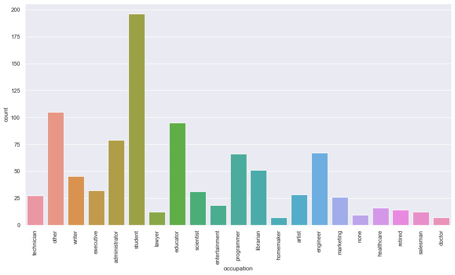

```python
plt.figure(figsize=(15,8))
sns.countplot(User['occupation'])
plt.xticks(rotation=90)
plt.show()
```

### 8. Visualize how popularity of genres has changed over the years - 10 marks

Note that you need to use the number of releases in a year as a parameter of popularity of a genre

Hint

1: you need to reach to a data frame where the release year is the index and the genre is the column names (one cell shows the number of release in a year in one genre) or vice versa. Once that is achieved, you can either use univariate plots or can use the heatmap to visualise all the changes over the years in one go.

Hint 2: Use groupby on the relevant column and use sum() on the same to find out the number of releases in a year/genre.

```python
genre_year = Item.groupby('release year').sum()
print(genre_year)
```

```
              movie id  unknown  Action  Adventure  Animation  Childrens  \
release year
1922               675        0       0          0          0          0
1926              1542        0       0          0          0          0
1930               617        0       0          0          0          0
1931               656        0       0          0          0          0
1932              1124        0       0          0          0          0
...                ...      ...     ...        ...        ...        ...
1994            189000        0      30         13          4         15
1995            183514        0      40         22          6         21
1996            322295        0      44         24          9         21
1997            253649        0      46         20          3         22
1998             75341        0      12          3          0          1

              Comedy  Crime  Documentary  Drama  Fantasy  Film-Noir  Horror  \
```

[output cut: 28 more lines]

```python
genre_year = genre_year.drop(columns = 'movie id').T
genre_year
```

| release year | 1922 | 1926 | 1930 | 1931 | 1932 | 1933 | 1934 | 1935 | 1936 | 1937 | ... | 1989 | 1990 | 1991 | 1992 | 1993 | 1994 | 1995 | 1996 | 1997 | 1998 |
| --- | --- | --- | --- | --- | --- | --- | --- | --- | --- | --- | --- | --- | --- | --- | --- | --- | --- | --- | --- | --- | --- |
| unknown | 0 | 0 | 0 | 0 | 0 | 0 | 0 | 0 | 0 | 0 | ... | 0 | 0 | 0 | 0 | 0 | 0 | 0 | 0 | 0 | 0 |
| Action | 0 | 0 | 0 | 0 | 0 | 0 | 0 | 0 | 0 | 0 | ... | 6 | 7 | 2 | 8 | 20 | 30 | 40 | 44 | 46 | 12 |
| Adventure | 0 | 0 | 0 | 0 | 0 | 0 | 0 | 0 | 0 | 0 | ... | 4 | 1 | 1 | 1 | 9 | 13 | 22 | 24 | 20 | 3 |
| Animation | 0 | 0 | 0 | 0 | 0 | 0 | 0 | 0 | 0 | 1 | ... | 0 | 0 | 1 | 2 | 1 | 4 | 6 | 9 | 3 | 0 |
| Childrens | 0 | 0 | 0 | 0 | 0 | 0 | 0 | 0 | 0 | 1 | ... | 0 | 1 | 1 | 1 | 6 | 15 | 21 | 21 | 22 | 1 |
| Comedy | 0 | 0 | 0 | 0 | 0 | 1 | 2 | 2 | 1 | 2 | ... | 3 | 6 | 6 | 12 | 39 | 82 | 63 | 108 | 87 | 13 |
| Crime | 0 | 0 | 0 | 1 | 0 | 0 | 0 | 0 | 0 | 0 | ... | 1 | 3 | 0 | 5 | 7 | 8 | 11 | 21 | 30 | 7 |
| Documentary | 0 | 0 | 0 | 0 | 0 | 0 | 0 | 0 | 0 | 0 | ... | 0 | 2 | 1 | 0 | 4 | 9 | 5 | 18 | 6 | 3 |
| Drama | 0 | 1 | 1 | 0 | 0 | 0 | 1 | 0 | 1 | 1 | ... | 8 | 12 | 11 | 14 | 64 | 97 | 89 | 170 | 113 | 33 |
| Fantasy | 0 | 0 | 0 | 0 | 0 | 0 | 0 | 0 | 0 | 0 | ... | 0 | 0 | 1 | 0 | 0 | 3 | 3 | 6 | 4 | 1 |
| Film-Noir | 0 | 0 | 0 | 1 | 0 | 0 | 0 | 0 | 0 | 0 | ... | 0 | 1 | 0 | 0 | 1 | 0 | 1 | 1 | 2 | 2 |
| Horror | 1 | 0 | 0 | 0 | 0 | 0 | 0 | 1 | 0 | 0 | ... | 0 | 1 | 1 | 6 | 5 | 8 | 14 | 11 | 8 | 4 |
| Musical | 0 | 0 | 0 | 0 | 0 | 0 | 1 | 1 | 0 | 3 | ... | 0 | 0 | 2 | 1 | 2 | 2 | 3 | 9 | 5 | 1 |
| Mystery | 0 | 0 | 0 | 0 | 0 | 0 | 1 | 0 | 0 | 0 | ... | 0 | 0 | 0 | 1 | 6 | 2 | 5 | 6 | 18 | 3 |
| Romance | 0 | 0 | 0 | 0 | 1 | 1 | 1 | 1 | 0 | 2 | ... | 1 | 4 | 0 | 7 | 16 | 35 | 37 | 38 | 51 | 11 |
| Sci-Fi | 0 | 0 | 0 | 0 | 0 | 0 | 0 | 0 | 0 | 0 | ... | 2 | 0 | 4 | 3 | 8 | 7 | 15 | 15 | 13 | 5 |
| Thriller | 0 | 0 | 0 | 1 | 0 | 0 | 0 | 1 | 0 | 0 | ... | 2 | 4 | 3 | 5 | 17 | 25 | 39 | 47 | 54 | 18 |
| War | 0 | 0 | 0 | 0 | 1 | 1 | 0 | 0 | 0 | 0 | ... | 2 | 0 | 1 | 2 | 4 | 7 | 5 | 9 | 14 | 0 |
| Western | 0 | 0 | 0 | 0 | 0 | 0 | 0 | 0 | 0 | 0 | ... | 0 | 2 | 0 | 1 | 2 | 6 | 2 | 2 | 0 | 0 |

19 rows × 71 columns

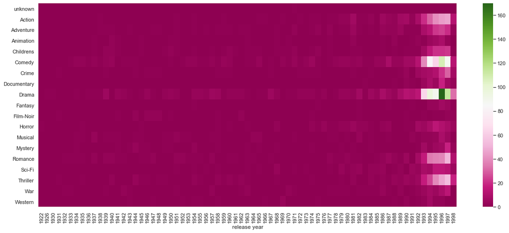

```python
plt.figure(figsize=(20,8))
sns.heatmap(genre_year, cmap='PiYG')  #heat map to plot the above table
plt.show()
```

Hint :

1. First find the movies that have more than 100 ratings(use merge, groupby and count). Extract the movie titles in a list.
2. Find the average rating of all the movies and sort them in the descending order. You will have to use the .merge() function to reach to a data set through which you can get the names and the average rating.
3. Use isin(list obtained from 1) to filter out the movies which have more than 100 ratings.

Note: This question will need you to research about groupby and apply your findings. You can find more on groupby on https://realpython.com/pandas-groupby/.

```python
Data.head()
```

|  | user id | movie id | rating | timestamp |
| --- | --- | --- | --- | --- |
| 0 | 196 | 242 | 3 | 881250949 |
| 1 | 186 | 302 | 3 | 891717742 |
| 2 | 22 | 377 | 1 | 878887116 |
| 3 | 244 | 51 | 2 | 880606923 |
| 4 | 166 | 346 | 1 | 886397596 |

```python
User.head()
```

|  | user id | age | gender | occupation | zip code |
| --- | --- | --- | --- | --- | --- |
| 0 | 1 | 24 | M | technician | 85711 |
| 1 | 2 | 53 | F | other | 94043 |
| 2 | 3 | 23 | M | writer | 32067 |
| 3 | 4 | 24 | M | technician | 43537 |
| 4 | 5 | 33 | F | other | 15213 |

```python
UD = User.merge(Data, on='user id')
UD.head()
```

|  | user id | age | gender | occupation | zip code | movie id | rating | timestamp |
| --- | --- | --- | --- | --- | --- | --- | --- | --- |
| 0 | 1 | 24 | M | technician | 85711 | 61 | 4 | 878542420 |
| 1 | 1 | 24 | M | technician | 85711 | 189 | 3 | 888732928 |
| 2 | 1 | 24 | M | technician | 85711 | 33 | 4 | 878542699 |
| 3 | 1 | 24 | M | technician | 85711 | 160 | 4 | 875072547 |
| 4 | 1 | 24 | M | technician | 85711 | 20 | 4 | 887431883 |

```python
UD.shape
```

```
(100000, 8)
```

```python
Item.head()
```

|  | movie id | movie title | release date | unknown | Action | Adventure | Animation | Childrens | Comedy | Crime | ... | Film-Noir | Horror | Musical | Mystery | Romance | Sci-Fi | Thriller | War | Western | release year |
| --- | --- | --- | --- | --- | --- | --- | --- | --- | --- | --- | --- | --- | --- | --- | --- | --- | --- | --- | --- | --- | --- |
| 0 | 1 | Toy Story | 01-Jan-1995 | 0 | 0 | 0 | 1 | 1 | 1 | 0 | ... | 0 | 0 | 0 | 0 | 0 | 0 | 0 | 0 | 0 | 1995 |
| 1 | 2 | GoldenEye | 01-Jan-1995 | 0 | 1 | 1 | 0 | 0 | 0 | 0 | ... | 0 | 0 | 0 | 0 | 0 | 0 | 1 | 0 | 0 | 1995 |
| 2 | 3 | Four Rooms | 01-Jan-1995 | 0 | 0 | 0 | 0 | 0 | 0 | 0 | ... | 0 | 0 | 0 | 0 | 0 | 0 | 1 | 0 | 0 | 1995 |
| 3 | 4 | Get Shorty | 01-Jan-1995 | 0 | 1 | 0 | 0 | 0 | 1 | 0 | ... | 0 | 0 | 0 | 0 | 0 | 0 | 0 | 0 | 0 | 1995 |
| 4 | 5 | Copycat | 01-Jan-1995 | 0 | 0 | 0 | 0 | 0 | 0 | 1 | ... | 0 | 0 | 0 | 0 | 0 | 0 | 1 | 0 | 0 | 1995 |

5 rows × 23 columns

```python
UDI = Item.merge(UD, on='movie id')
UDI.head()
```

|  | movie id | movie title | release date | unknown | Action | Adventure | Animation | Childrens | Comedy | Crime | ... | War | Western | release year | user id | age | gender | occupation | zip code | rating | timestamp |
| --- | --- | --- | --- | --- | --- | --- | --- | --- | --- | --- | --- | --- | --- | --- | --- | --- | --- | --- | --- | --- | --- |
| 0 | 1 | Toy Story | 01-Jan-1995 | 0 | 0 | 0 | 1 | 1 | 1 | 0 | ... | 0 | 0 | 1995 | 1 | 24 | M | technician | 85711 | 5 | 874965758 |
| 1 | 1 | Toy Story | 01-Jan-1995 | 0 | 0 | 0 | 1 | 1 | 1 | 0 | ... | 0 | 0 | 1995 | 2 | 53 | F | other | 94043 | 4 | 888550871 |
| 2 | 1 | Toy Story | 01-Jan-1995 | 0 | 0 | 0 | 1 | 1 | 1 | 0 | ... | 0 | 0 | 1995 | 5 | 33 | F | other | 15213 | 4 | 875635748 |
| 3 | 1 | Toy Story | 01-Jan-1995 | 0 | 0 | 0 | 1 | 1 | 1 | 0 | ... | 0 | 0 | 1995 | 6 | 42 | M | executive | 98101 | 4 | 883599478 |
| 4 | 1 | Toy Story | 01-Jan-1995 | 0 | 0 | 0 | 1 | 1 | 1 | 0 | ... | 0 | 0 | 1995 | 10 | 53 | M | lawyer | 90703 | 4 | 877888877 |

5 rows × 30 columns

```python
UDI.info()
```

```
<class 'pandas.core.frame.DataFrame'>
Int64Index: 99991 entries, 0 to 99990
Data columns (total 30 columns):
 #   Column        Non-Null Count  Dtype
---  ------        --------------  -----
 0   movie id      99991 non-null  int64
 1   movie title   99991 non-null  object
 2   release date  99991 non-null  object
 3   unknown       99991 non-null  int64
 4   Action        99991 non-null  int64
 5   Adventure     99991 non-null  int64
 6   Animation     99991 non-null  int64
 7   Childrens     99991 non-null  int64
 8   Comedy        99991 non-null  int64
 9   Crime         99991 non-null  int64
```

[output cut: 22 more lines]

```python
UDI.groupby(['movie id','movie title'])['rating'].count().reset_index()
```

|  | movie id | movie title | rating |
| --- | --- | --- | --- |
| 0 | 1 | Toy Story | 452 |
| 1 | 2 | GoldenEye | 131 |
| 2 | 3 | Four Rooms | 90 |
| 3 | 4 | Get Shorty | 209 |
| 4 | 5 | Copycat | 86 |
| ... | ... | ... | ... |
| 1676 | 1678 | Mat' i syn | 1 |
| 1677 | 1679 | B. Monkey | 1 |
| 1678 | 1680 | Sliding Doors | 1 |
| 1679 | 1681 | You So Crazy | 1 |
| 1680 | 1682 | Scream of Stone (Schrei aus Stein) | 1 |

1681 rows × 3 columns

```python
movie_100 = UDI.groupby(['movie id','movie title'])['rating'].count().sort_values(ascending=False).reset_index()
movie_100
```

|  | movie id | movie title | rating |
| --- | --- | --- | --- |
| 0 | 50 | Star Wars | 583 |
| 1 | 258 | Contact | 509 |
| 2 | 100 | Fargo | 508 |
| 3 | 181 | Return of the Jedi | 507 |
| 4 | 294 | Liar Liar | 485 |
| ... | ... | ... | ... |
| 1676 | 1564 | To Cross the Rubicon | 1 |
| 1677 | 1565 | Daens | 1 |
| 1678 | 1566 | Man from Down Under, The | 1 |
| 1679 | 1567 | Careful | 1 |
| 1680 | 1682 | Scream of Stone (Schrei aus Stein) | 1 |

1681 rows × 3 columns

```python
movie_top25 = movie_100
movie_top25.head(25)
```

|  | movie id | movie title | rating |
| --- | --- | --- | --- |
| 0 | 50 | Star Wars | 583 |
| 1 | 258 | Contact | 509 |
| 2 | 100 | Fargo | 508 |
| 3 | 181 | Return of the Jedi | 507 |
| 4 | 294 | Liar Liar | 485 |
| 5 | 286 | English Patient, The | 481 |
| 6 | 288 | Scream | 478 |
| 7 | 1 | Toy Story | 452 |
| 8 | 300 | Air Force One | 431 |
| 9 | 121 | Independence Day (ID4) | 429 |
| 10 | 174 | Raiders of the Lost Ark | 420 |
| 11 | 127 | Godfather, The | 413 |
| 12 | 56 | Pulp Fiction | 394 |
| 13 | 7 | Twelve Monkeys | 392 |
| 14 | 98 | Silence of the Lambs, The | 390 |
| 15 | 237 | Jerry Maguire | 384 |
| 16 | 117 | Rock, The | 378 |
| 17 | 172 | Empire Strikes Back, The | 367 |
| 18 | 222 | Star Trek: First Contact | 365 |
| 19 | 204 | Back to the Future | 350 |
| 20 | 313 | Titanic | 350 |
| 21 | 405 | Mission: Impossible | 344 |
| 22 | 79 | Fugitive, The | 336 |
| 23 | 210 | Indiana Jones and the Last Crusade | 331 |
| 24 | 151 | Willy Wonka and the Chocolate Factory | 326 |

### 10. See gender distribution across different genres check for the validity of the below statements - 10 marks

- Men watch more drama than women
- Women watch more Sci-Fi than men
- Men watch more Romance than women
1. There is no need to conduct statistical tests around this. Just compare the percentages and comment on the validity of the above statements.
2. you might want ot use the .sum(), .div() function here.
3. Use number of ratings to validate the numbers. For example, if out of 4000 ratings received by women, 3000 are for drama, we will assume that 75% of the women watch drama.

**TH Note ..** Genre by Gender = GG = sum of UDI grouped by gender

```python
GG = UDI.groupby('gender').sum().loc[:,'Action':'Western']
GG
```

| gender | Action | Adventure | Animation | Childrens | Comedy | Crime | Documentary | Drama | Fantasy | Film-Noir | Horror | Musical | Mystery | Romance | Sci-Fi | Thriller | War | Western |
| --- | --- | --- | --- | --- | --- | --- | --- | --- | --- | --- | --- | --- | --- | --- | --- | --- | --- | --- |
| F | 5442 | 3141 | 995 | 2232 | 8068 | 1794 | 187 | 11008 | 363 | 385 | 1197 | 1442 | 1314 | 5858 | 2629 | 5086 | 2189 | 371 |
| M | 20147 | 10612 | 2610 | 4950 | 21764 | 6261 | 571 | 28887 | 989 | 1348 | 4120 | 3512 | 3931 | 13603 | 10101 | 16786 | 7209 | 1483 |

```python
GG.shape
```

```
(2, 19)
```

```python
GG['Total'],GG.sum(axis=1)
GG
```

[output not shown]

```python
GG.div(GG.Total, axis= 0) * 100
```

| gender | Action | Adventure | Animation | Childrens | Comedy | Crime | Documentary | Drama | Fantasy | Film-Noir | Horror | Musical | Mystery | Romance | Sci-Fi | Thriller | War | Western | Total |
| --- | --- | --- | --- | --- | --- | --- | --- | --- | --- | --- | --- | --- | --- | --- | --- | --- | --- | --- | --- |
| F | 5.066945 | 2.924527 | 0.926426 | 2.078174 | 7.511964 | 1.670360 | 0.174112 | 10.249344 | 0.337983 | 0.358466 | 1.114504 | 1.342619 | 1.223441 | 5.454275 | 2.447813 | 4.73548 | 2.038137 | 0.345431 | 100.0 |
| M | 6.340160 | 3.339543 | 0.821354 | 1.557740 | 6.849022 | 1.970305 | 0.179691 | 9.090594 | 0.311233 | 0.424209 | 1.296543 | 1.105209 | 1.237066 | 4.280796 | 3.178734 | 5.28247 | 2.268636 | 0.466693 | 100.0 |

#### Conclusion:

**In Drama** 10.24% Women : 9.09% Men .. therefore statement is **False**

**In Sci-Fi** 2.4% Women : 3.17% Men .. therefore statement is **False**

**In Romance** 5.45% Women:4.28% Men .. therefore statement is **False**